# Testis-restricted microproteins | RNASeq

Marta Espinosa

2024-05-13

## Human Data | RNASeq

### Load Table of Counts (input data)

Obtained using STAR to align and featureCounts to quantify.

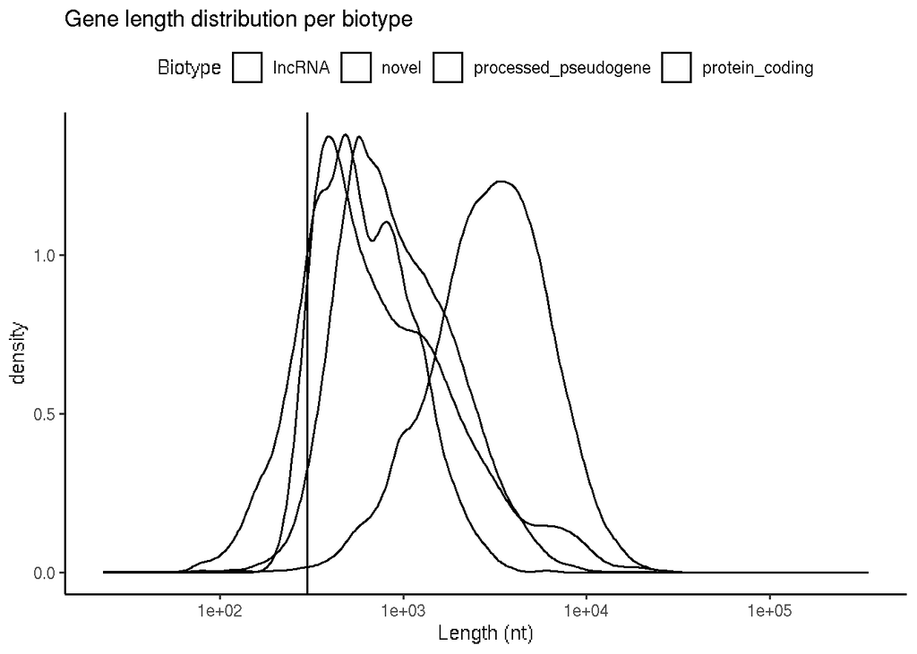

```
## [1] 79294    15
```

```
##     transcript_id human_brain_rna_1 human_brain_rna_2 human_brain_rna_3
## 1 ENST00000000233        109.555779         66.825116         119.95551
## 2 ENST00000000412         33.550536         26.095890          37.39917
## 3 ENST00000001008         42.689573         44.028889          57.91506
## 4 ENST00000001146         17.874206          8.102100          24.12909
## 5 ENST00000002125         19.448022          9.285777          23.10912
## 6 ENST00000002165          9.064656         11.283541          12.05064
##   human_liver_rna_1 human_liver_rna_2 human_liver_rna_3 human_testis_rna_1
## 1         30.070979        81.5289260         83.030945           75.35264
## 2         20.834294        10.6216179         13.834916           48.03512
## 3         16.439585        35.6182272         40.510421           91.11600
## 4          0.103834         0.4036608          1.130843           18.43829
## 5          2.599274         1.1788966          1.676153           98.51802
## 6         18.268155        10.5255449         19.839908           13.78981
##   human_testis_rna_2 human_testis_rna_3 chr         gene_id gene_name
## 1          39.290891         205.082566   7 ENSG00000004059      ARF5
## 2          15.095547          41.129284  12 ENSG00000003056      M6PR
## 3          71.189027          66.658656  12 ENSG00000004478     FKBP4
## 4           7.414740          30.764352   2 ENSG00000003137   CYP26B1
## 5          60.049857           6.509373   2 ENSG00000003509   NDUFAF7
## 6           4.786365          20.547915   6 ENSG00000001036     FUCA2
##   transcript_type      gene_type
## 1  protein_coding protein_coding
## 2  protein_coding protein_coding
## 3  protein_coding protein_coding
## 4  protein_coding protein_coding
## 5  protein_coding protein_coding
## 6  protein_coding protein_coding
```

### TPM normalization of raw counts

The expression counts data is normalized in transcript per million (TPM).

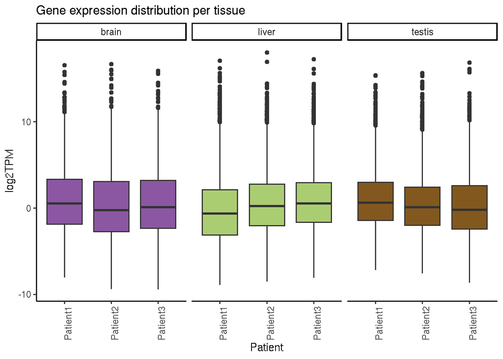

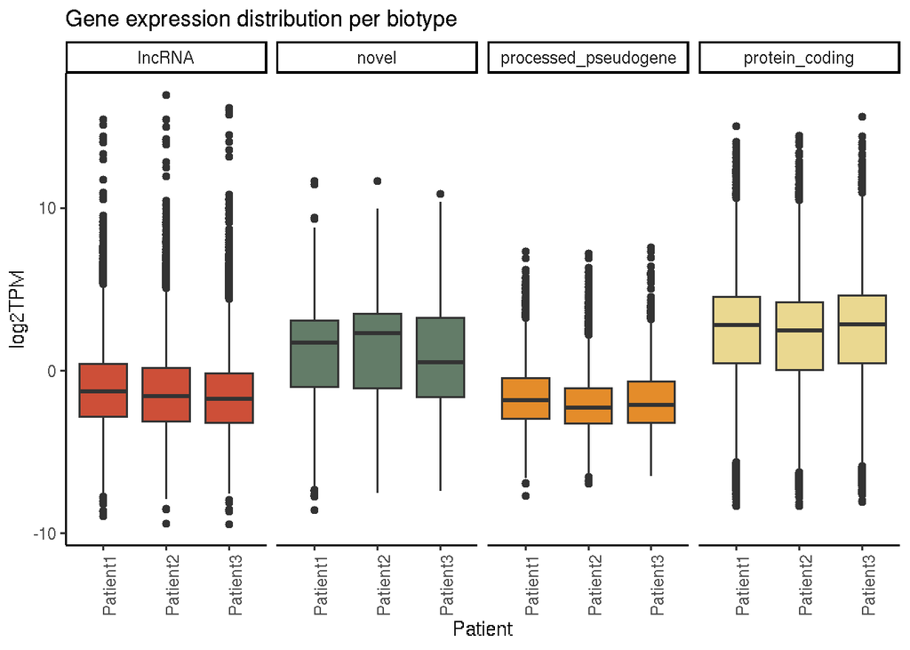

### Testis-Expressed | RNASeq

- > 1 TPM in at least 1 sample

```
## [1] "brain"
```

```
##
##               lncRNA                novel processed_pseudogene
##                 4410                  251                  830
##       protein_coding
##                14453
```

```
## [1] "liver"
```

```
##
##               lncRNA                novel processed_pseudogene
##                 2148                  174                  318
##       protein_coding
##                12747
```

```
## [1] "testis"
```

```
##
##               lncRNA                novel processed_pseudogene
##                11362                  604                 1161
##       protein_coding
##                16529
```

### Testis-Restricted | RNASeq

In this case, we want to determine testis specific genes. For that matter, the following criteria was applied:

- CRITERIA 2: TPM > 1 in at least 1 testis sample and TPM < 0.5 in all other tissues

The same is performed for the rest tissues.

```
## [1] "brain"
```

```
##
##               lncRNA                novel processed_pseudogene
##                  940                   32                  212
##       protein_coding
##                  234
```

```
## [1] "liver"
```

```
##
##               lncRNA                novel processed_pseudogene
##                  398                   31                   32
##       protein_coding
##                  170
```

```
## [1] "testis"
```

```
##
##               lncRNA                novel processed_pseudogene
##                 6907                  356                  474
##       protein_coding
##                 1437
```

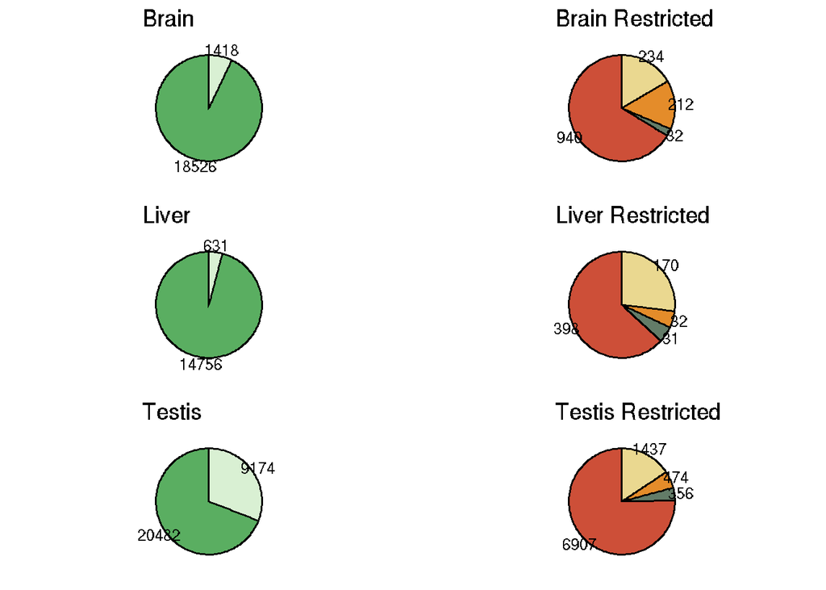

### Testis-Restricted | RNASeq & GTEx filter

We will use GTEx to filter those genes whose expression in other tissues is higher than 0.5.

In cases where several “sub-tissues” are available, we kept the highest value.

```
## [1] 58988
```

```
## [1] 9174
```

```
## [1] 5358   33
```

```
## [1] 5358    4
```

```
## [1] 5358   30
```

```
## [1] 5358   33
```

```
## [1] 5358    3
```

```
## [1] 5358   15
```

```
## [1] 2658   15
```

```
## [1] 3014
```

```
##
##               lncRNA                novel processed_pseudogene
##                 1992                  356                  179
##       protein_coding
##                  487
```

**Of the expressed, how many are restricted based on Wang and based on GTEx?**

```
##
##               lncRNA                novel processed_pseudogene
##                11362                  604                 1161
##       protein_coding
##                16529
```

```
##
##                           no   yes
##   lncRNA                4455  6907
##   novel                  248   356
##   processed_pseudogene   687   474
##   protein_coding       15092  1437
```

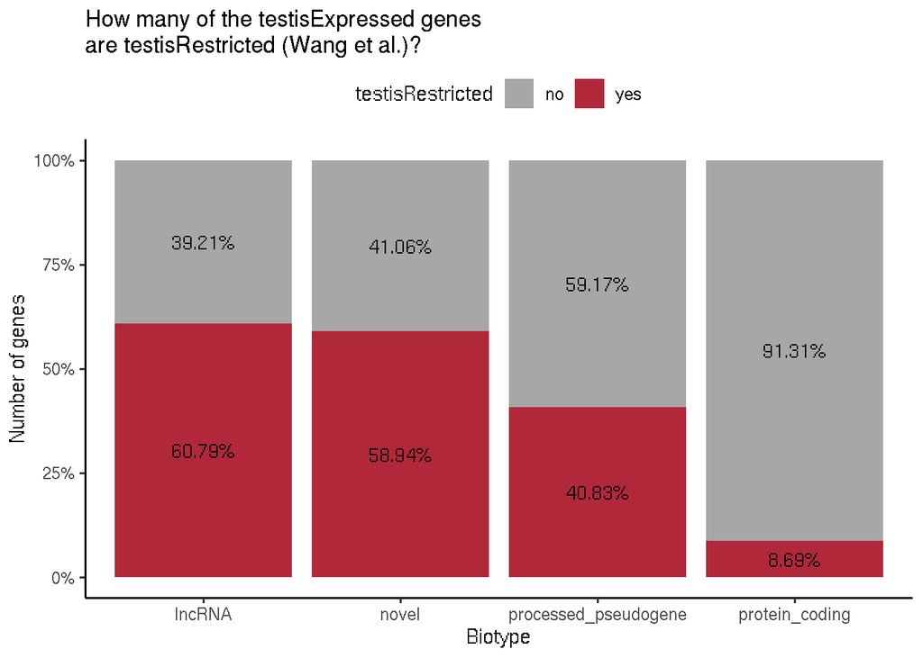

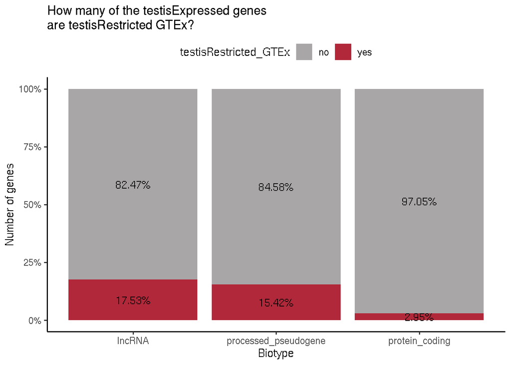

### Testis-Restricted | only GTEx filter

If we only use GTEx to filter those genes whose expression in other tissues is higher than 0.5… without Wang.

```
## [1] 29656
```

```
## [1] 23467    33
```

```
## [1] 23467     4
```

```
## [1] 23467    30
```

```
## [1] 23467    33
```

```
## [1] 23467     3
```

```
##
##               lncRNA processed_pseudogene       protein_coding
##                 6263                 1120                16084
```

```
## [1] 23467    15
```

```
## [1] 2984   15
```

```
## [1] 3588
```

```
##
##               lncRNA                novel processed_pseudogene
##                 2225                  604                  224
##       protein_coding
##                  535
```

## LIVER-RESTRICTED

```
## [1] 62 15
```

```
## [1] 93
```

```
##
##               lncRNA                novel processed_pseudogene
##                   39                   31                    5
##       protein_coding
##                   18
```

## BRAIN-RESTRICTED

```
## [1] 164  15
```

```
## [1] 196
```

```
##
##               lncRNA                novel processed_pseudogene
##                  129                   32                   16
##       protein_coding
##                   19
```

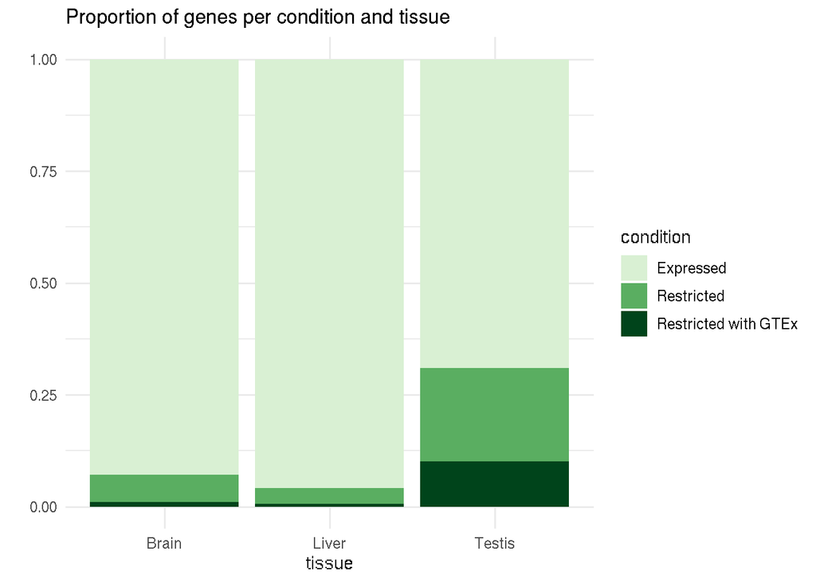

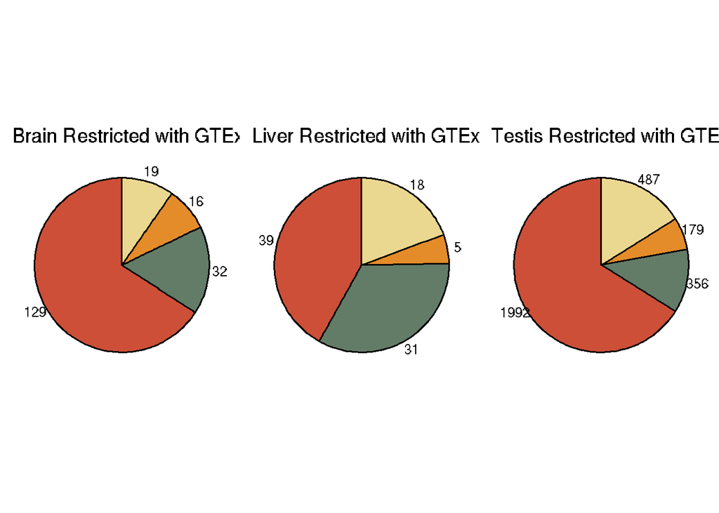

## Human Data | RiboSeq

#### Testis-Expressed with RiboSeq

```
##
##               lncRNA                novel processed_pseudogene
##                 2359                  136                 1405
##       protein_coding
##                23351
```

```
##
##               lncRNA_noncoding                novel_noncoding
##                           2359                            136
## processed_pseudogene_noncoding       protein_coding_canonical
##                           1405                          15469
##            protein_coding_dORF           protein_coding_odORF
##                           2228                            316
##           protein_coding_ouORF            protein_coding_uORF
##                           1212                           4126
```

```
## [1] 29656
```

```
##
##               lncRNA                novel processed_pseudogene
##                11362                  604                 1161
##       protein_coding
##                16529
```

```
## [1] 25100
```

```
## [1] "orfs"
```

```
##
##               lncRNA                novel processed_pseudogene
##                 2106                  121                  302
##       protein_coding
##                22571
```

```
## [1] "altORFs"
```

```
##
##               lncRNA_noncoding                novel_noncoding
##                           2106                            121
## processed_pseudogene_noncoding       protein_coding_canonical
##                            302                          14742
##            protein_coding_dORF           protein_coding_odORF
##                           2219                            312
##           protein_coding_ouORF            protein_coding_uORF
##                           1199                           4099
```

```
## [1] "genes"
```

```
##
##               lncRNA                novel processed_pseudogene
##                 1516                   55                  206
##       protein_coding
##                15055
```

```
## [1] "orfs testis-restricted"
```

```
##
##       lncRNA novel processed_pseudogene protein_coding
##   no    1194    16                  164          21218
##   yes    912   105                  138           1353
```

```
## [1] "altORFs testis-restricted"
```

```
##
##       lncRNA_noncoding novel_noncoding processed_pseudogene_noncoding
##   no              1194              16                            164
##   yes              912             105                            138
##
##       protein_coding_canonical protein_coding_dORF protein_coding_odORF
##   no                     13695                2158                  285
##   yes                     1047                  61                   27
##
##       protein_coding_ouORF protein_coding_uORF
##   no                  1124                3956
##   yes                   75                 143
```

```
## [1] "genes testis-restricted"
```

```
##
##               lncRNA                novel processed_pseudogene
##                  704                   41                   94
##       protein_coding
##                 1084
```

```
##
##                        lncRNA_noncoding novel_noncoding
##   lncRNA                            704               0
##   novel                               0              41
##   processed_pseudogene                0               0
##   protein_coding                      0               0
##
##                        processed_pseudogene_noncoding protein_coding_canonical
##   lncRNA                                            0                        0
##   novel                                             0                        0
##   processed_pseudogene                             94                        0
##   protein_coding                                    0                     1047
##
##                        protein_coding_dORF protein_coding_odORF
##   lncRNA                                 0                    0
##   novel                                  0                    0
##   processed_pseudogene                   0                    0
##   protein_coding                        53                   27
##
##                        protein_coding_ouORF protein_coding_uORF
##   lncRNA                                  0                   0
##   novel                                   0                   0
##   processed_pseudogene                    0                   0
##   protein_coding                         75                 121
```

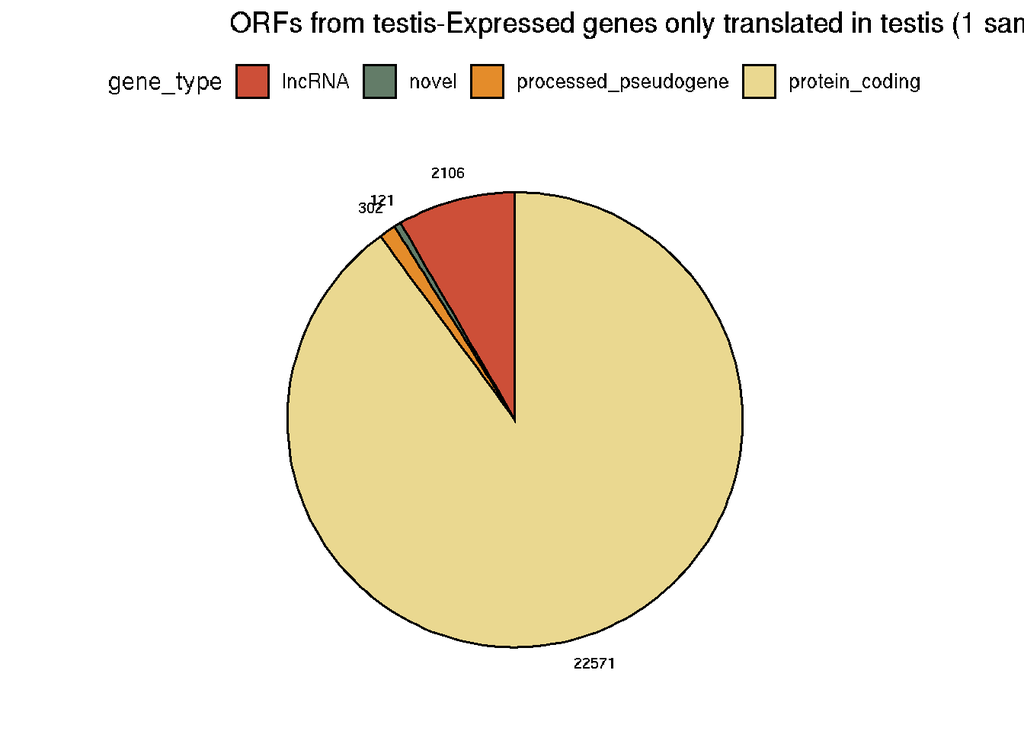

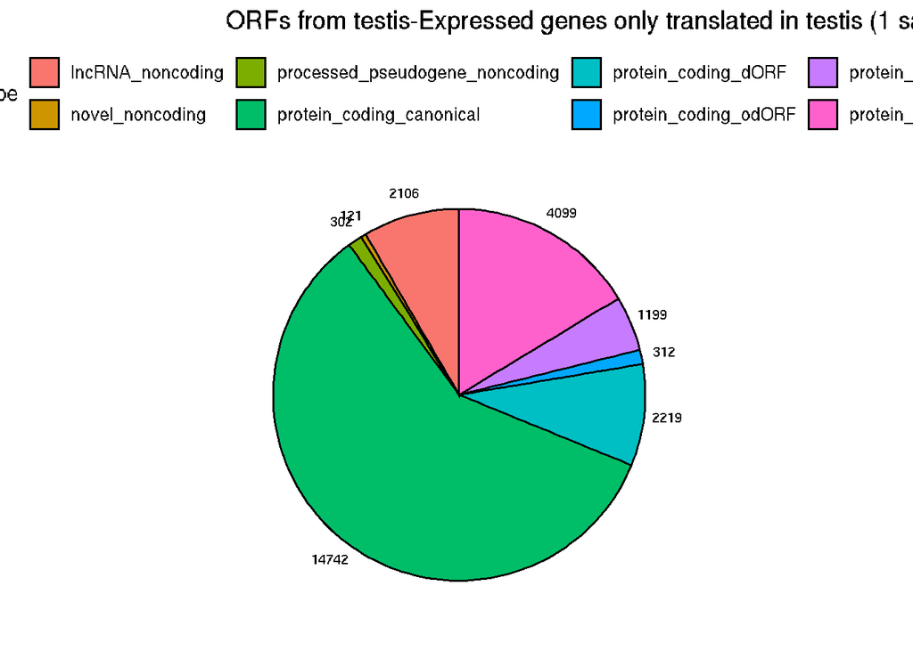

#### Testis-Specific with RiboSeq

```
## [1] 1046
```

```
## [1] "orfs"
```

```
##
##               lncRNA                novel processed_pseudogene
##                  338                  105                   76
##       protein_coding
##                  527
```

```
## [1] "altORFs"
```

```
##
##               lncRNA_noncoding                novel_noncoding
##                            338                            105
## processed_pseudogene_noncoding       protein_coding_canonical
##                             76                            377
##            protein_coding_dORF           protein_coding_odORF
##                             32                             14
##           protein_coding_ouORF            protein_coding_uORF
##                             35                             69
```

```
## [1] "genes"
```

```
##
##               lncRNA                novel processed_pseudogene
##                  261                   41                   51
##       protein_coding
##                  391
```

```
##
##                        lncRNA_noncoding novel_noncoding
##   lncRNA                            261               0
##   novel                               0              41
##   processed_pseudogene                0               0
##   protein_coding                      0               0
##
##                        processed_pseudogene_noncoding protein_coding_canonical
##   lncRNA                                            0                        0
##   novel                                             0                        0
##   processed_pseudogene                             51                        0
##   protein_coding                                    0                      377
##
##                        protein_coding_dORF protein_coding_odORF
##   lncRNA                                 0                    0
##   novel                                  0                    0
##   processed_pseudogene                   0                    0
##   protein_coding                        28                   14
##
##                        protein_coding_ouORF protein_coding_uORF
##   lncRNA                                  0                   0
##   novel                                   0                   0
##   processed_pseudogene                    0                   0
##   protein_coding                         35                  56
```

```
## [1] 1046   11
```

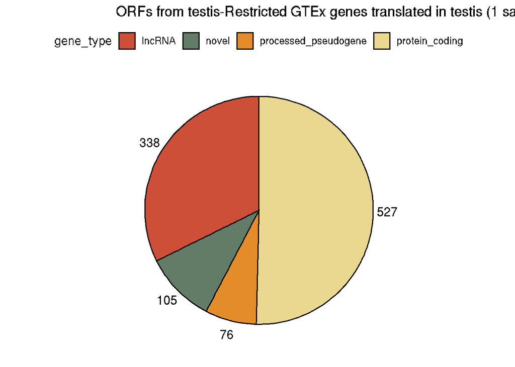

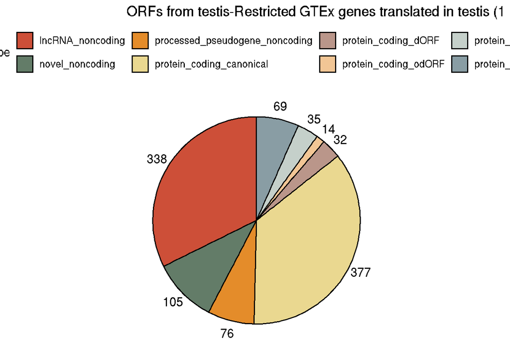

```
## [1] "ONLY GTEx"
```

```
## [1] 1159
```

```
## [1] "orfs"
```

```
##
##               lncRNA                novel processed_pseudogene
##                  365                  121                   96
##       protein_coding
##                  577
```

```
## [1] "altORFs"
```

```
##
##               lncRNA_noncoding                novel_noncoding
##                            365                            121
## processed_pseudogene_noncoding       protein_coding_canonical
##                             96                            411
##            protein_coding_dORF           protein_coding_odORF
##                             34                             15
##           protein_coding_ouORF            protein_coding_uORF
##                             36                             81
```

```
## [1] "genes"
```

```
##
##               lncRNA                novel processed_pseudogene
##                  280                   55                   63
##       protein_coding
##                  428
```

```
##
##                        lncRNA_noncoding novel_noncoding
##   lncRNA                            280               0
##   novel                               0              55
##   processed_pseudogene                0               0
##   protein_coding                      0               0
##
##                        processed_pseudogene_noncoding protein_coding_canonical
##   lncRNA                                            0                        0
##   novel                                             0                        0
##   processed_pseudogene                             63                        0
##   protein_coding                                    0                      411
##
##                        protein_coding_dORF protein_coding_odORF
##   lncRNA                                 0                    0
##   novel                                  0                    0
##   processed_pseudogene                   0                    0
##   protein_coding                        30                   15
##
##                        protein_coding_ouORF protein_coding_uORF
##   lncRNA                                  0                   0
##   novel                                   0                   0
##   processed_pseudogene                    0                   0
##   protein_coding                         36                  66
```

```
## [1] 1159   11
```

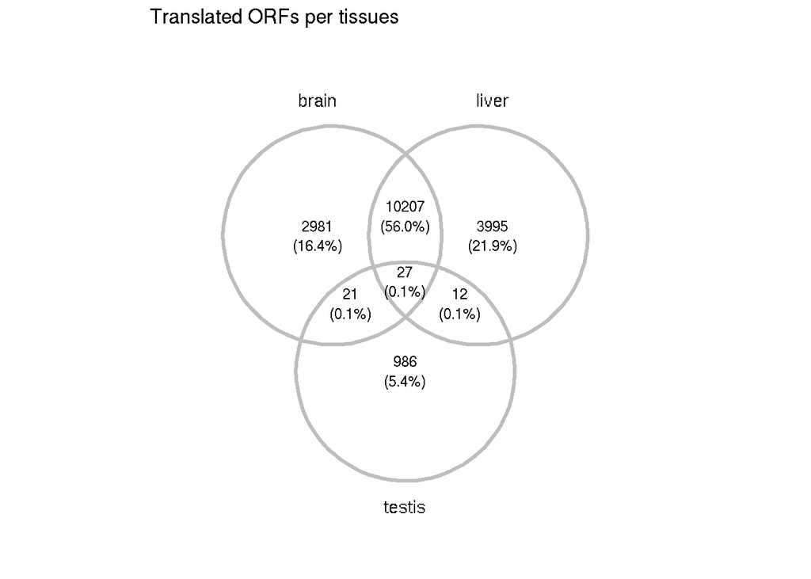

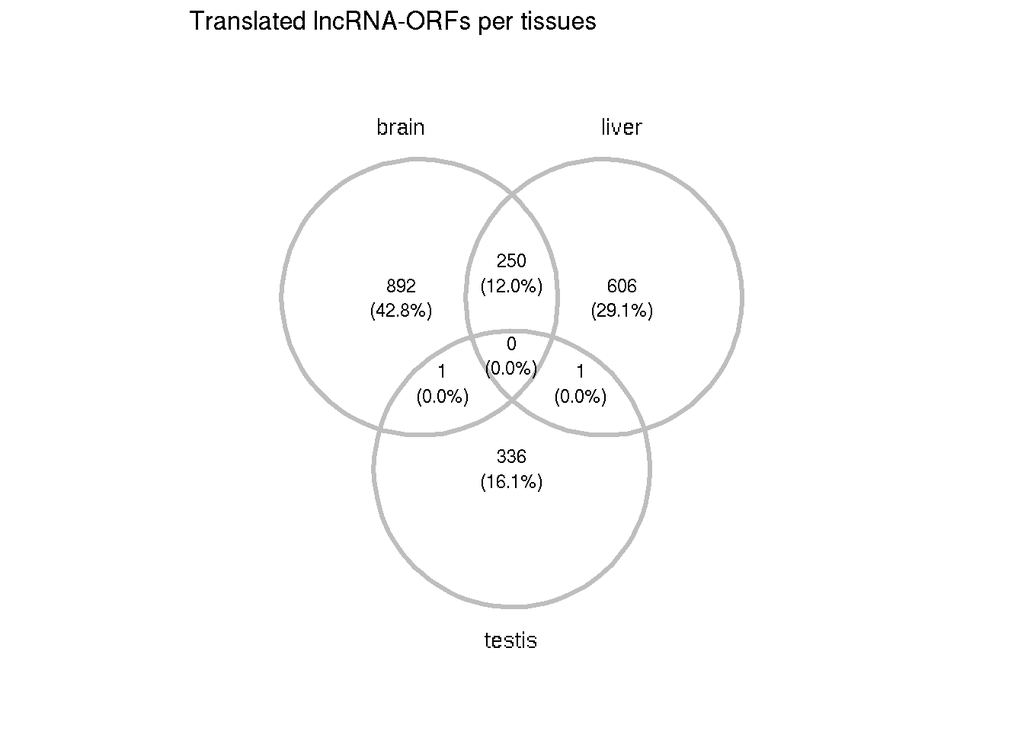

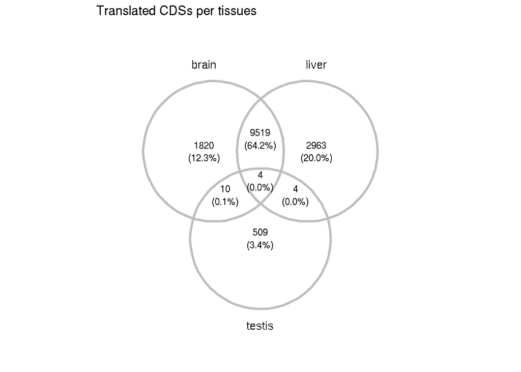

```
## [1] "orfs"
```

```
##
##               lncRNA                novel processed_pseudogene
##                  336                  105                   36
##       protein_coding
##                  509
```

```
## [1] "altORFs"
```

```
##
##               lncRNA_noncoding                novel_noncoding
##                            336                            105
## processed_pseudogene_noncoding       protein_coding_canonical
##                             36                            359
##            protein_coding_dORF           protein_coding_odORF
##                             32                             14
##           protein_coding_ouORF            protein_coding_uORF
##                             35                             69
```

```
## [1] "genes"
```

```
##
##               lncRNA_noncoding                novel_noncoding
##                            259                             41
## processed_pseudogene_noncoding       protein_coding_canonical
##                             27                            359
##            protein_coding_dORF           protein_coding_odORF
##                             28                             14
##           protein_coding_ouORF            protein_coding_uORF
##                             35                             56
```

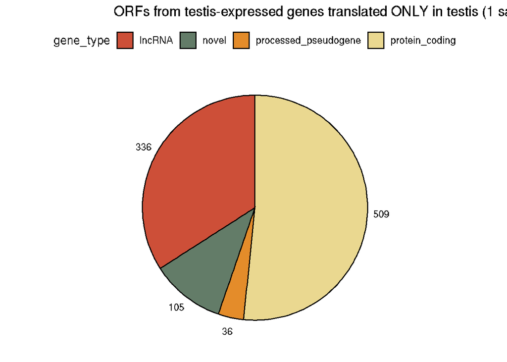

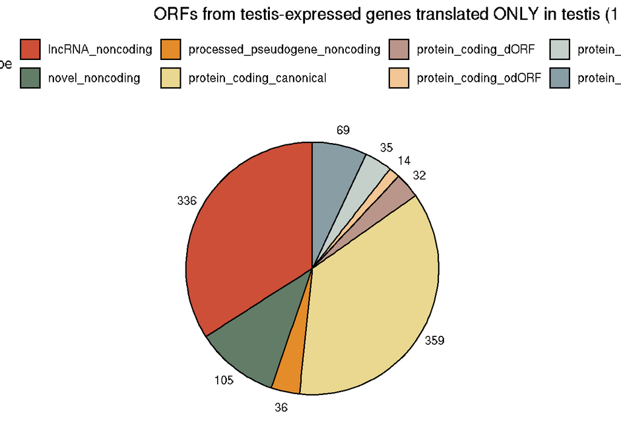

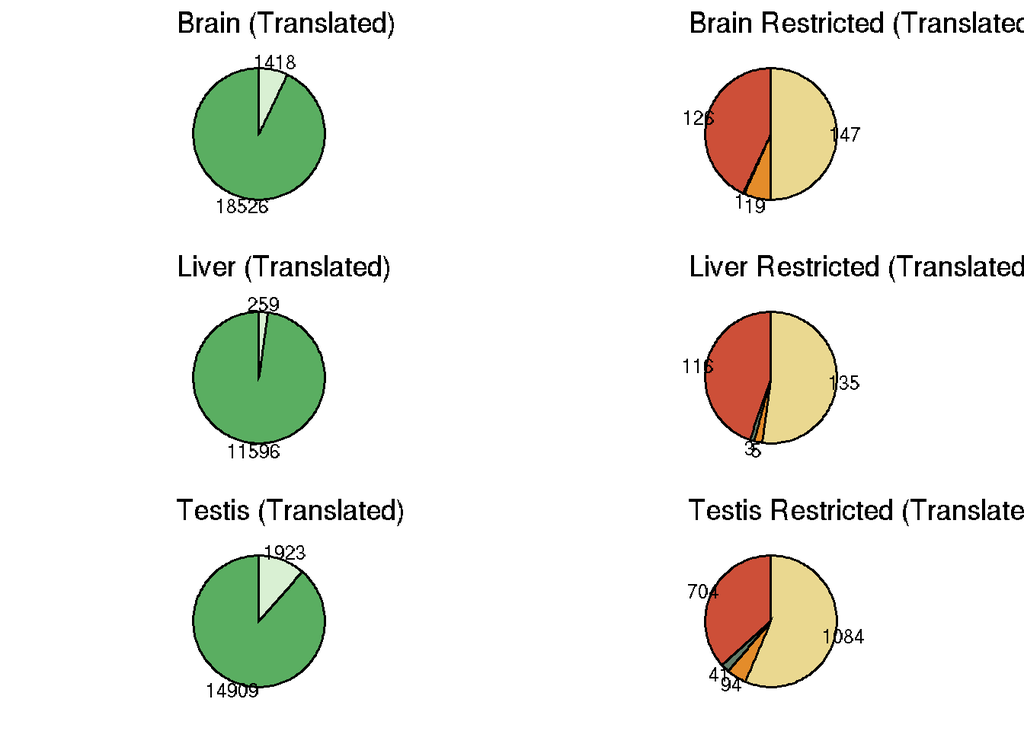

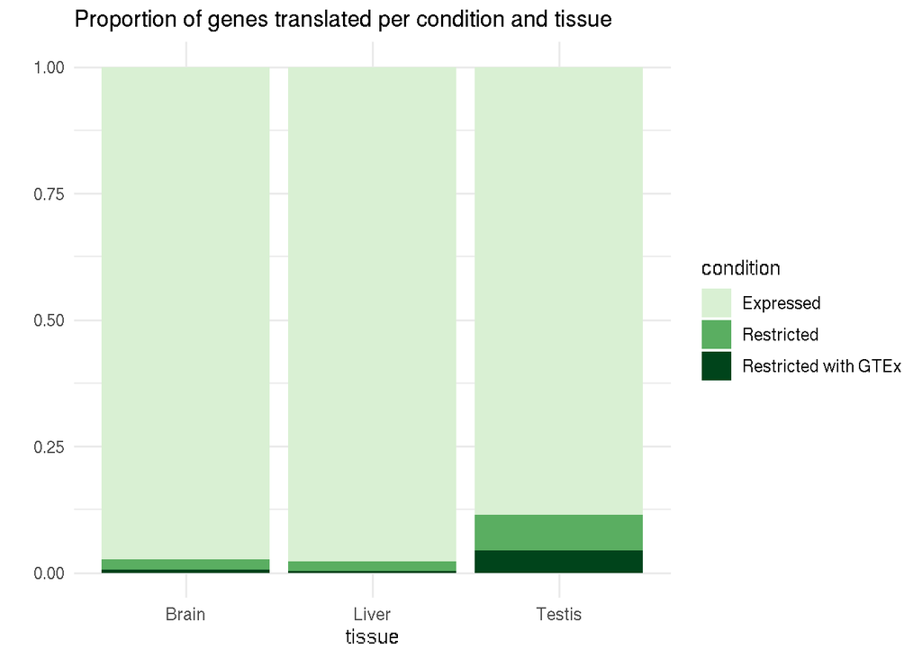

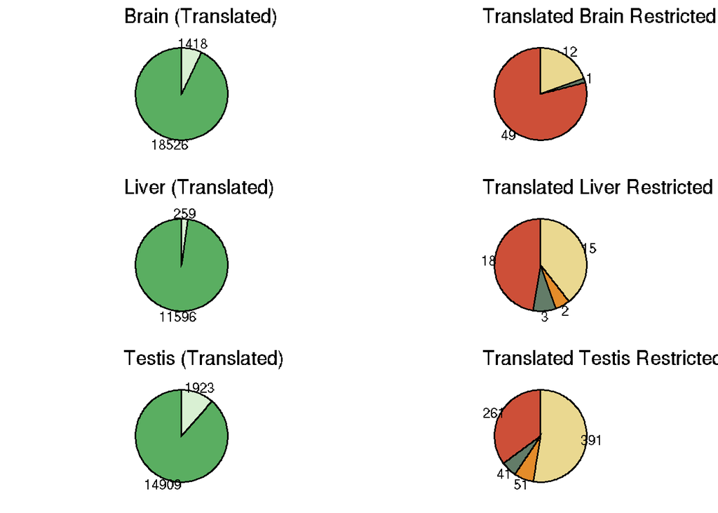

## CTDB

```
## [1] 276
```

```
## [1] 217
```

```
##
##   A   X
## 146  71
```

```
## [1] 142
```

```
## [1] 134
```